# Alignment of ddRAD-seq reads to genome assembly.

Mar Llaberia-Robledillo & J. Ignacio Lucas Lledó

2025-03-03

## Mapping

The mapping of reads to the reference genome is done with `bwa-mem2` below.

```bash
ASM=../2023-05-15/assembly.fasta
PATHFQ=../2023-05-17/crepi_edits

if [ ! -d BAM ]; then mkdir BAM; fi
if [ ! -e ${ASM}.0123 ]; then
   bwa-mem2 index $ASM
fi

for i in $(ls $PATHFQ/*.trimmed_R1_.fastq.gz); do
   SAMPLE=$(basename $i .trimmed_R1_.fastq.gz)
   if [ ! -e BAM/${SAMPLE}.bam ]; then
      if [ ! -e BAM/${SAMPLE}_on_ref.sam ]; then
         bwa-mem2 mem -t 24 $ASM ${PATHFQ}/${SAMPLE}.trimmed_R1_.fastq.gz \
                                 ${PATHFQ}/${SAMPLE}.trimmed_R2_.fastq.gz \
                 -R "@RG\tID:${SAMPLE}\tSM:${SAMPLE}" > BAM/${SAMPLE}_on_ref.sam \
                 2>> bwamem2.err
      fi
      samtools sort BAM/${SAMPLE}_on_ref.sam -o BAM/temp_sorted.bam
      samtools view -b -F 4 -q 20 BAM/temp_sorted.bam > BAM/${SAMPLE}.bam
      rm BAM/temp_sorted.bam
   fi
   if [ ! -e BAM/${SAMPLE}.bam.bai ]; then
      samtools index BAM/${SAMPLE}.bam
   fi
done
#rm BAM/*.sam
```

I didn’t get mapping statistics before filtering the sorted BAM files. Thus, all reads in the currently saved BAM files must be mapped. In order to get the efficiency of the mapping, I need to compare the number of reads mapped (not the number of *mappings*, since some reads have supplemental or secondary mappings) with the number of reads filtered `2023-05-17/crepi_edits`.

```bash
S2=../2023-05-17/crepi_edits/s2_rawedit_stats.txt
if [ ! -e summary_mapping.txt ]; then
   echo -e "sample\ttotal\tmapped" > summary_mapping.txt
   for SAMPLE in $(ls 1 BAM/*.bam | xargs basename -s .bam); do
      TOTAL=$(grep $SAMPLE $S2 | gawk '{print $9}')
      MAPPED=$(samtools flagstats BAM/$SAMPLE.bam | grep "primary mapped" | cut -d " " -f 1)
      echo -e "$SAMPLE\t$TOTAL\t$MAPPED" >> summary_mapping.txt
   done
fi
```

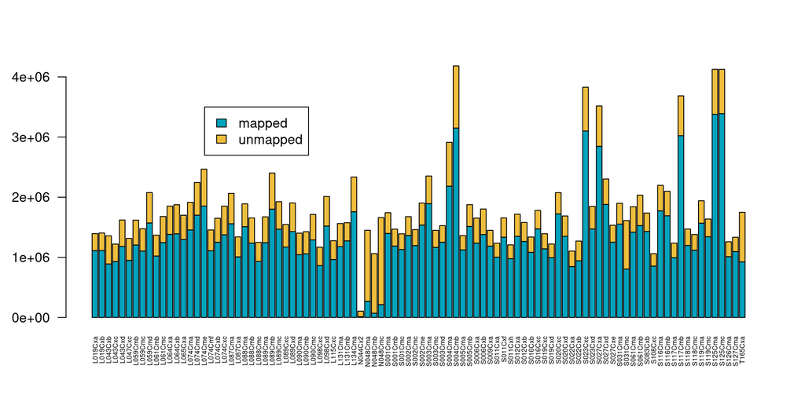

```r
library(MetBrewer)
mappings <- read.table('summary_mapping.txt', header = TRUE)
mappings$unmapped <- mappings$total - mappings$mapped
z <- as.matrix(t(mappings[, c('mapped', 'unmapped')]))
colnames(z) <- mappings$sample
barplot(z, col = met.brewer('Lakota', 2),
        cex.names = 0.5, las = 2)
legend(20, 3.5e+06, c('mapped', 'unmapped'), fill = met.brewer('Lakota', 2))
```

Curiously, the three samples from Bienne with a decent number of reads, N048Cma, N048Cmb and N048Cmc, get most of their reads wasted during mapping, as if they were more distant from the assembly than the rest.

## SNP calling

GATK4’s `HaplotypeCaller` re-assembles every region with any evidence of variation. I suppose that’s why GATK4 does not implement the `IndelRealigner`.

If `samtools` worked well, read groups must be correctly assigned, and we do not need to use `AddOrReplaceReadGroups`.

```bash
ASM=../2023-05-15/assembly.fasta
PATHFQ=../2023-05-17/crepi_edits
GATK=/opt/gatk-4.4.0.0/gatk

DICT=$(dirname $ASM)/$(basename -s .fasta $ASM).dict
if [ ! -e $DICT ]; then
   $GATK CreateSequenceDictionary -R $ASM -O $DICT
fi

if [ ! -e $ASM.fai ]; then
   samtools faidx $ASM
fi

SAMPLES=""
for data in $(ls BAM/*.bam); do
   SAMPLES=$SAMPLES" -I "$data
done

if [ ! -e crepi.vcf ]; then
   $GATK --java-options "-XX:ConcGCThreads=1 -Xmx100G"  \
         HaplotypeCaller -R $ASM -O crepi.vcf $SAMPLES 1> gatk.log 2> gatk.err
fi
```

## SNP filtering

```bash
if [ ! -e crepi.recode.vcf ]; then
   vcftools --vcf crepi.vcf \
            --out crepi \
            --minGQ 5 \
            --thin 200 \
            --max-missing 0.2 \
            --min-alleles 2 \
            --max-alleles 2 \
            --remove-indels \
            --recode --recode-INFO-all 1> vcftools.log 2> vcftools.err
fi
```

```r
library('vcfR')
```

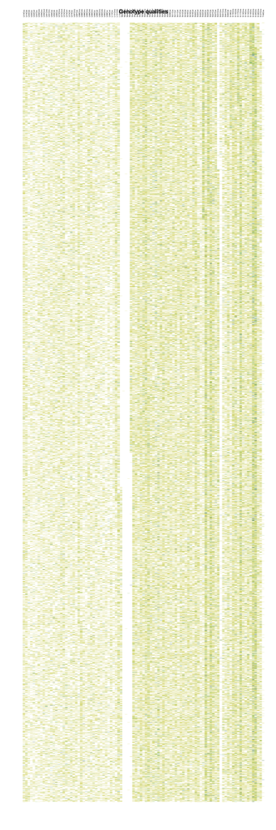

```r
library('MetBrewer')
vcf <- read.vcfR('crepi.recode.vcf', verbose = FALSE)
gts <- matrix(
   as.numeric(
      sapply(strsplit(vcf@gt[,-1], ':'), '[', 4)
   ),
   ncol = ncol(vcf@gt)
)
image(t(gts), col = met.brewer('Hokusai3', 5),
      axes = FALSE, main = 'Genotype qualities')
axis(3, at = 0:95 / 95, labels = colnames(vcf@gt)[-1], las=2,
     cex.axis = 0.4, tick = FALSE, line = FALSE)
```

The image of genotype qualities shows:

1. Better genotype qualities in Suopatjavri than in Langfjordvatn.
2. Individuals from Bienne or Thun with insufficient genotypes.
3. Some individuals have genotypes only among the largest or among the smallest contigs. Why?